# 과제 #3

Ban Eu Jin

11 5월, 2020

ClimateChange.csv 파일은 1983년 5월부터 2008년 12월까지의 지구의 평균적인 대기 질 및 기후 관련 데이터를 포함한다. 변수에 대한 상세한 설명을 아래와 같다. 이를 활용하여 세계의 평균 기온을 예측하기 위한 모델을 만들어 보고자 한다. Temp 변수를 target으로, Year 및 Month를 제외한 나머지 8개의 변수를 feature로 사용하자.

• Year : 관측 년도

• Month : 관측 월

• Temp : 세계 평균 기온 (기준값 대비 차이)

• CFC.11 : 대기 중 CFC-11 프레온가스 농도 (단위: ppbv)

• CFC.12 : 대기 중 CFC-12 프레온가스 농도 (단위: ppbv)

• CO2 : 대기 중 이산화탄소 농도 (단위: ppmv)

• N2O : 대기 중 아산화질소 농도 (단위: ppmv)

• CH4 : 대기 중 메탄 농도 (단위: ppmv)

• Aerosols : The mean stratospheric aerosol optical depth - 성층권 에어로졸 깊이

• TSI : The total solar irradiance - 대기 중 단위 면적당 태양에너지

• MEI : Multivariate El Nino Southern Oscillation index - 태평양에서의 기후 효과의 강도에 대한 척도

### 1. Year 및 Month를 제외한 9개의 변수들 간의 상관 관계를 다양한 그래프를 활용하여 시각화해보고, 이로부터 데이터의 특성을 분석해보자.

```r
library(ggplot2)
library(caret)
library(ISLR)
library(rsample)
library(PerformanceAnalytics)
library(corrplot)
library(leaps)
library(glmnet)
library(vip)
```

```r
getwd()
```

```
## [1] "C:/Users/djwls/OneDrive/문서/Rmarkdown"
```

```r
climate=read.csv("ClimateChange.csv")
str(climate)
```

```
## 'data.frame':    308 obs. of  11 variables:
##  $ Year    : int  1983 1983 1983 1983 1983 1983 1983 1983 1984 1984 ...
##  $ Month   : int  5 6 7 8 9 10 11 12 1 2 ...
##  $ MEI     : num  2.556 2.167 1.741 1.13 0.428 ...
##  $ CO2     : num  346 346 344 342 340 ...
##  $ CH4     : num  1639 1634 1633 1631 1648 ...
##  $ N2O     : num  304 304 304 304 304 ...
##  $ CFC.11  : num  191 192 193 194 194 ...
##  $ CFC.12  : num  350 352 354 356 357 ...
##  $ TSI     : num  1366 1366 1366 1366 1366 ...
##  $ Aerosols: num  0.0863 0.0794 0.0731 0.0673 0.0619 0.0569 0.0524 0.0486 0.0451 0.0416 ...
##  $ Temp    : num  0.109 0.118 0.137 0.176 0.149 0.093 0.232 0.078 0.089 0.013 ...
```

```r
climate=climate[-1:-2] #Year ,Month제거
cor(climate)
```

```
##                  MEI         CO2        CH4         N2O      CFC.11      CFC.12
## MEI       1.00000000 -0.15291104 -0.1055547 -0.16237531  0.08817074 -0.03983567
## CO2      -0.15291104  1.00000000  0.8722531  0.98113544  0.40128447  0.82321031
## CH4      -0.10555472  0.87225311  1.0000000  0.89440921  0.71350408  0.95823718
## N2O      -0.16237531  0.98113544  0.8944092  1.00000000  0.41215475  0.83929545
## CFC.11    0.08817074  0.40128447  0.7135041  0.41215475  1.00000000  0.83138131
## CFC.12   -0.03983567  0.82321031  0.9582372  0.83929545  0.83138131  1.00000000
## TSI      -0.07682560  0.01786672  0.1463349  0.03989183  0.28462884  0.18927009
## Aerosols  0.35235073 -0.36926514 -0.2903814 -0.35349882 -0.03230227 -0.24378508
## Temp      0.13529168  0.74850465  0.6996966  0.74324183  0.38011134  0.68894411
##                  TSI    Aerosols       Temp
## MEI      -0.07682560  0.35235073  0.1352917
## CO2       0.01786672 -0.36926514  0.7485046
## CH4       0.14633495 -0.29038142  0.6996966
## N2O       0.03989183 -0.35349882  0.7432418
## CFC.11    0.28462884 -0.03230227  0.3801113
## CFC.12    0.18927009 -0.24378508  0.6889441
## TSI       1.00000000  0.08323812  0.1821856
## Aerosols  0.08323812  1.00000000 -0.3920694
## Temp      0.18218561 -0.39206945  1.0000000
```

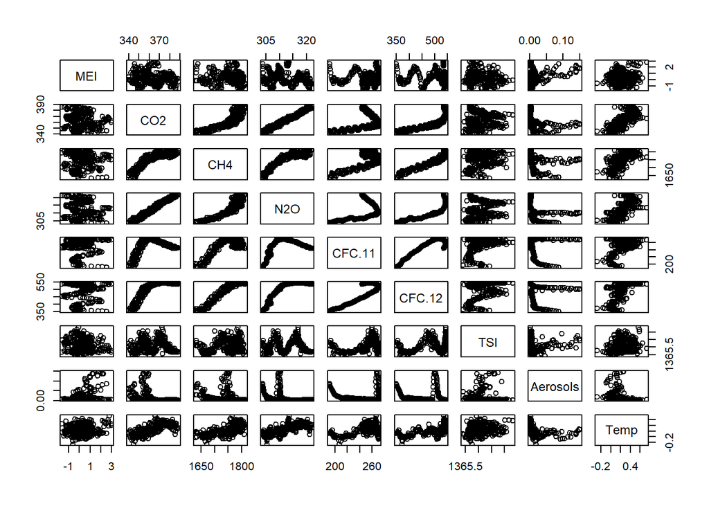

```r
# 각각의 변수에 대한 상관관계
#-1.0과 -0.7 사이이면, 강한 음적 선형관계,
#-0.7과 -0.3 사이이면, 뚜렷한 음적 선형관계,
#-0.3과 -0.1 사이이면, 약한 음적 선형관계,
#-0.1과 +0.1 사이이면, 거의 무시될 수 있는 선형관계,
#+0.1과 +0.3 사이이면, 약한 양적 선형관계,
#+0.3과 +0.7 사이이면, 뚜렷한 양적 선형관계,
#+0.7과 +1.0 사이이면, 강한 양적 선형관계
plot(climate) #상관관계 그래프
```

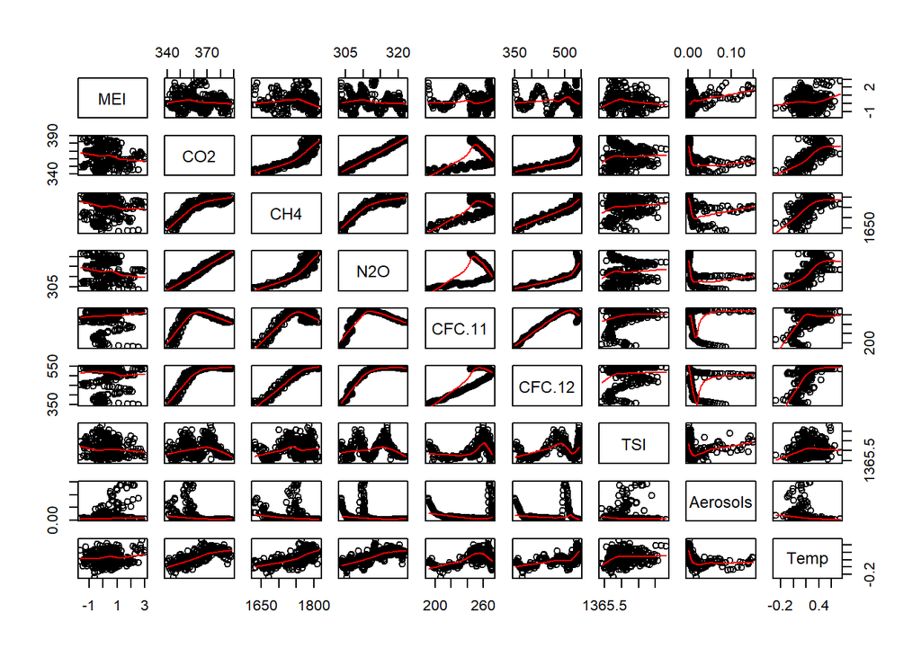

```r
pairs(climate,panel=panel.smooth) #추세선
```

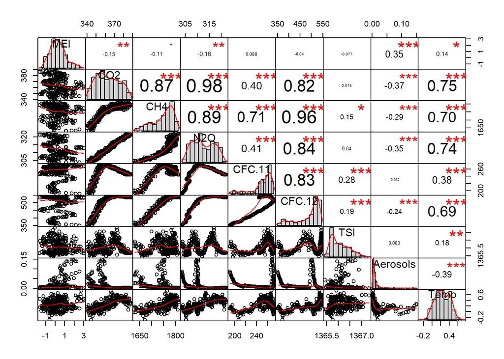

```r
chart.Correlation(climate,histogram = T,pch=19)#히스토그램,상관관계 R값 , 추세선 *의 갯수가 많을 수록상관관계가 있다고 볼 수 있다.
```

```r
# ***인 변수들은 (MEI,Aerosois),(CO2,CH4),(CO2,N2O),(CO2,CFC.11),(CO2,CFC.12),(CO2,Aerosois),(CO2,Temp) 등등이 있다.
climate.cor=cor(climate)
climate.cor
```

```
##                  MEI         CO2        CH4         N2O      CFC.11      CFC.12
## MEI       1.00000000 -0.15291104 -0.1055547 -0.16237531  0.08817074 -0.03983567
## CO2      -0.15291104  1.00000000  0.8722531  0.98113544  0.40128447  0.82321031
## CH4      -0.10555472  0.87225311  1.0000000  0.89440921  0.71350408  0.95823718
## N2O      -0.16237531  0.98113544  0.8944092  1.00000000  0.41215475  0.83929545
## CFC.11    0.08817074  0.40128447  0.7135041  0.41215475  1.00000000  0.83138131
## CFC.12   -0.03983567  0.82321031  0.9582372  0.83929545  0.83138131  1.00000000
## TSI      -0.07682560  0.01786672  0.1463349  0.03989183  0.28462884  0.18927009
## Aerosols  0.35235073 -0.36926514 -0.2903814 -0.35349882 -0.03230227 -0.24378508
## Temp      0.13529168  0.74850465  0.6996966  0.74324183  0.38011134  0.68894411
##                  TSI    Aerosols       Temp
## MEI      -0.07682560  0.35235073  0.1352917
## CO2       0.01786672 -0.36926514  0.7485046
## CH4       0.14633495 -0.29038142  0.6996966
## N2O       0.03989183 -0.35349882  0.7432418
## CFC.11    0.28462884 -0.03230227  0.3801113
## CFC.12    0.18927009 -0.24378508  0.6889441
## TSI       1.00000000  0.08323812  0.1821856
## Aerosols  0.08323812  1.00000000 -0.3920694
## Temp      0.18218561 -0.39206945  1.0000000
```

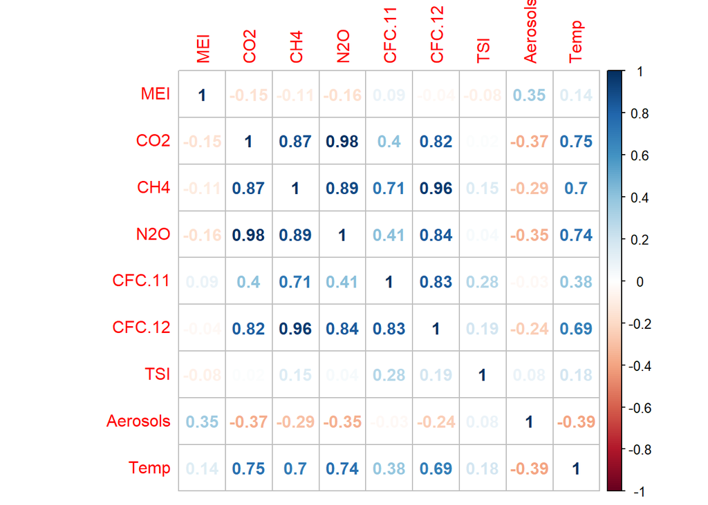

```r
corrplot(climate.cor,method="number") #상관관계를 숫자로 표현
```

### 2. 2004년 이후의 데이터를 test set으로 2003년까지의 데이터를 training set으로 분할하자. 그리고 training set을 활용하여 linear regression model을 수립하자. 이때 8개의 feature변수를 모두 포함 시킨다.